# Homework

Ján Gašper

1 apríla 2019

Dáta `dt_pol_w_claims` už mám načítané. Ideme rozdeliť dáta na tréningové a validačné. Validačných dát bude $q=5\%$. Budeme sa zaoberať iba dátami pre súkromné autá, ktoré sú poistené na nenulovú sumu. Ideme skúsiť predikovať, či bude mať daný zákazník nulový burning cost, alebo nie.

```r
setwd("D:/GeneralInsurance_Class")
dt_pol_w_claims <- readRDS("Data/dt_pol_w_claims.rds")
dt_homework <- dt_pol_w_claims[dt_pol_w_claims$Veh_type1 == "private car",]
na.omit(dt_homework)
```

[output not shown]

[output cut: 9771 more lines]

```r
dt_homework$NoBurn <- dt_homework$Burning_Cost <= 0
dt_homework <- dt_homework[dt_homework$Sum_insured > 0,]
n <- nrow(dt_homework)
set.seed(123456)
q <- .05
rnd <- runif(n)
dt_train <- dt_homework[rnd>q,]
dt_valid <- dt_homework[rnd<=q,]
```

D_age_banded

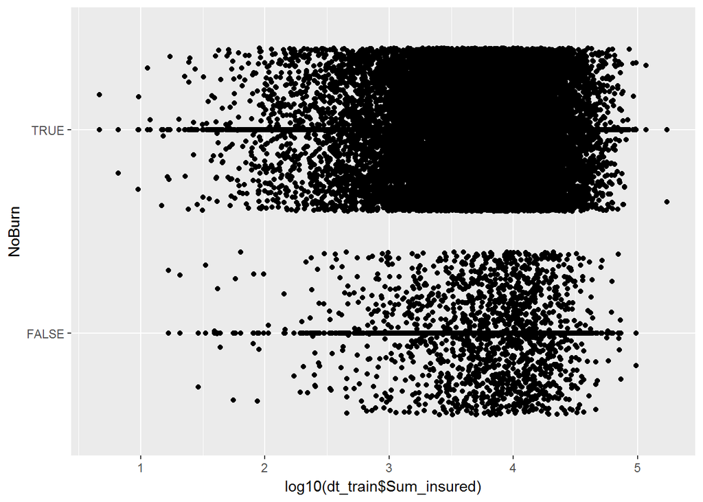

```r
library(ggplot2)
ggplot(data=dt_train, aes(x=log10(dt_train$Sum_insured), y=NoBurn)) + geom_point() + geom_jitter()
```

Vyzerá, že najviac tých, čo majú nenulový burning cost majú poistnú sumu okolo $10^4$. Stále je to však dosť málo.

Skúšal si urobiť vlastný model, kde pravdepodobnosť nulového burning costu budem modelovať ako
$$\Pr(BC =0) = \frac{p}{1+e^{-a_0 - a_1x}} + \frac{r}{1+e^{-b_0 - b_1x}}$$
kde $x$ je desiatkový logaritmus poistenej sumy. Tento postup ale zlyhal. Nájsť minimum tak plochej funkcie r-ko nezvládne.

Skúšam iný vlastný model. Pravdepodobnosť toho, že niekto bude mať nenulový burning cost budem modelovať z tréningových dát. Idme na to takto: Povedzme, že si niekto chce poistiť auto na sumu $1000$, čo je štvorciferné číslo. Pozrieme sa na to, koľko ľudí, ktorí sa poistili na sumu rádu $4 - b$ až $4 + b$ a aký podiel z nich nenulový burning cost. Tento podiel bude náš ohdad pravdepodobnosti. (Z matematického hľadiska ide o podiel dvoch konvolúcií s binárnou funkciou. Možno by bolo zaujímavé pozrieť sa, keby sme použili iné ako binárne jadro. Ale to za… ehm… hodinu na domácu úlohu… ehm… nestihnem. Aj tá funkcia `f` by sa dala urobiť vektorovo, ale meh…)

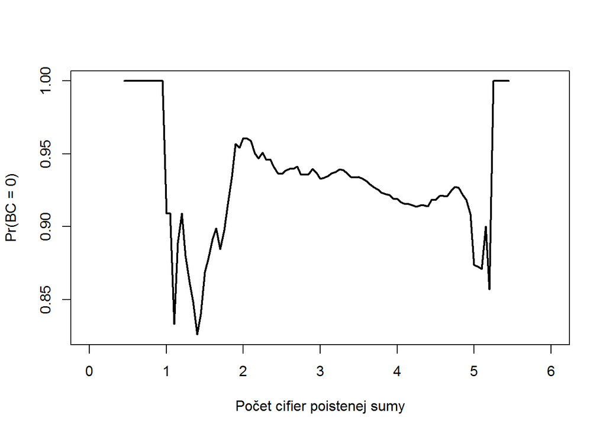

```r
f <- function(x, bw=.25){
  (sum(dt_train[dt_train$Sum_insured < 10^(x-bw),]$NoBurn) - sum(dt_train[dt_train$Sum_insured < 10^(x+bw),]$NoBurn)) / ((nrow(dt_train[dt_train$Sum_insured < 10^(x-bw),])) - (nrow(dt_train[dt_train$Sum_insured < 10^(x+bw),])))
}
x <- seq(0, 6, by=.05)
y <- x
for (i in 1:length(x)){
  y[i] <- f(x[i])
}

plot(x,y, "l", lwd=2, xlab="Počet cifier poistenej sumy", ylab="Pr(BC = 0)")
```

Poďme otestovať náš model napríklad v $L_1$ norme na validačných dátach: (Pozor, bude to trvať dlho, ozaj som to nestihol nakódiť dobre.)

```r
S <- 0
for (i in 1:nrow(dt_valid)){
  temp <- f(log10(dt_valid$Sum_insured[i]))
  if (!is.nan(temp)){
    S <- S + abs(dt_valid$NoBurn[i] - temp)
  }
}
S
```

```
## [1] 145.6279
```

Dostali sme číslo $145,6279$. Toto číslo bude miera nekvality nášho modelu - čím bude nižšia, tým lepší model máme.

Skúsme sa teraz pozrieť na “úbohý model” - budeme považovať pravdepodobnosť že burning cost je rovný nule za nezávislú od poistnej sumy (teda konštantnú). Odhadneme napríklad pomocou maxima vierohodnosti v $L_2$ norme. Využijeme poznatky z ekonometrie a uvedomíme si, že odhad bude vlastne priemer. Pozrieme sa, čo sa deje s odchýlkou:

```r
S <- sum(abs(dt_valid$NoBurn - mean(dt_train$NoBurn)))
S
```

```
## [1] 145.6403
```

Náš model je asi nafigu, pretože naša metrika ukazuje veľmi podobné číslo. Pre iný výber validačných dát by možno vyšla odchýlka aj väčšia.

Dobre, viac som toho nestihol. Ale išiel by som modelovať pre tých, čo majú nenulový burning cost na základe viacerých faktorov. Napríklad by som urbobil novú premennú, ktorá by bola rôzna pre každý typ zákazníka a každý vek. Zlúčil by som vekovú skupinu od 80 rokov nahor. Taktiež skupina <25 rokov by sa dala zlepiť s vými čo majú menej ako 30 rokov. Pre každú skupinu by sa dala robiť regresia zvlášť a hádam by sme na niečo prišli.

```r
"počty poistiek pre jednotlivé typy zákazníkov a vek"
```

```
## [1] "počty poistiek pre jednotlivé typy zákazníkov a vek"
```

```r
table(dt_train[,c("D_age_banded", "Customer_Type")])
```

```
##                  Customer_Type
## D_age_banded         C    S
##   100 <=  x < 105   66   14
##   105 <=  x < 110   28    3
##   25 <=  x < 30     54  115
##   30 <=  x < 35    375  172
##   35 <=  x < 40    574  234
##   40 <=  x < 45   5705  342
##   45 <=  x < 50   5951  391
##   50 <=  x < 55   2094  359
##   55 <=  x < 60   2190  270
##   60 <=  x < 65    521  159
##   65 <=  x < 70    414  125
##   70 <=  x < 75    140   30
##   75 <=  x < 80    118   20
##   80 <=  x < 85     43    3
##   85 <=  x < 90     35    9
##   90 <=  x < 95     41   11
##   95 <=  x < 100    12    2
##   Unknown           23    0
##   x < 25             1   26
##   x > 110            0    0
```

Toto by bolo treba nejako spraviť: dať tam novú premennú pre kartézky súčin vekových kategórii a typu zákazníka, pridať ďalšie premenné, otestovať štatistickú významnosť parametrov a pozrieť sa čo na to validačné dáta.

```r
HWModel2 <- glm(data=dt_train[dt_train$Burning_Cost>0,], formula = Burning_Cost ~ 1 + D_age_banded + Customer_Type, family=Gamma())

summary(HWModel2)
```

```
##
## Call:
## glm(formula = Burning_Cost ~ 1 + D_age_banded + Customer_Type,
##     family = Gamma(), data = dt_train[dt_train$Burning_Cost >
##         0, ])
##
## Deviance Residuals:
##     Min       1Q   Median       3Q      Max
## -3.2770  -1.3710  -0.8102  -0.1167   9.2532
##
## Coefficients:
##                              Estimate Std. Error t value Pr(>|t|)
## (Intercept)                  0.058319   0.057161   1.020    0.308
## D_age_banded105 <=  x < 110  0.306638   0.948136   0.323    0.746
## D_age_banded25 <=  x < 30    0.005879   0.078608   0.075    0.940
## D_age_banded30 <=  x < 35    0.008618   0.063399   0.136    0.892
## D_age_banded35 <=  x < 40    0.047843   0.070296   0.681    0.496
## D_age_banded40 <=  x < 45    0.038236   0.058334   0.655    0.512
## D_age_banded45 <=  x < 50    0.015981   0.057908   0.276    0.783
## D_age_banded50 <=  x < 55    0.016745   0.058917   0.284    0.776
## D_age_banded55 <=  x < 60    0.029297   0.060168   0.487    0.626
## D_age_banded60 <=  x < 65   -0.035863   0.057623  -0.622    0.534
## D_age_banded65 <=  x < 70   -0.023446   0.059676  -0.393    0.694
## D_age_banded70 <=  x < 75    0.010858   0.072311   0.150    0.881
## D_age_banded75 <=  x < 80   -0.029576   0.061970  -0.477    0.633
## D_age_banded80 <=  x < 85   -0.022706   0.070521  -0.322    0.748
## D_age_banded85 <=  x < 90    0.037821   0.255781   0.148    0.882
## D_age_banded90 <=  x < 95    0.083156   0.202925   0.410    0.682
## D_age_banded95 <=  x < 100  -0.006919   0.145032  -0.048    0.962
## D_age_bandedUnknown          0.173480   0.428871   0.405    0.686
## D_age_bandedx < 25           0.980693   1.940829   0.505    0.613
## Customer_TypeS               0.018919   0.017837   1.061    0.289
##
## (Dispersion parameter for Gamma family taken to be 6.724755)
##
##     Null deviance: 3394.3  on 1533  degrees of freedom
## Residual deviance: 3157.4  on 1514  degrees of freedom
## AIC: 10634
##
## Number of Fisher Scoring iterations: 10
```